# Wenatchee parent offspring regression

## Load and format pedigree and data

```r
library(MCMCglmm)
library(ggplot2)
library(sequoia)
library(pedtricks)
library(cowplot)
setwd("/Users/mike.ford/Documents/MikeFord/WenSpChkProp/FRANZWensp_analysis/Git-Wenatchee-RRS")

d = read.csv("pedigree_fitness_Tumwater_Grun_4.29.25.csv",stringsAsFactors = F,na.strings = "NA")
d$id = as.factor(d$id)
d$dam = as.factor(d$dam)
d$sire = as.factor(d$sire)
d = d[,c(3,1,2,4:ncol(d))]
names(d)[1] = "animal"

#### format run timing
d$Date.off = as.Date(d$Date.off,format = '%m/%d/%y')
temp = paste("1/1/",d$Year.off,sep="")
temp = as.Date(temp,format="%m/%d/%Y")
dayofyear = d$Date.off - temp
d$Dayofyear.off = dayofyear
d$Dayofyear.off = as.integer(d$Dayofyear.off)
mean(d$Dayofyear.off,na.rm=T)
```

```
[1] 185.1698
```

```r
sd(d$Dayofyear.off,na.rm=T)
```

```
[1] 14.83149
```

```r
d$Date.sire = as.Date(d$Date.sire,format = '%m/%d/%y')
temp = paste("1/1/",d$Year.sire,sep="")
temp = as.Date(temp,format="%m/%d/%Y")
dayofyear = d$Date.sire - temp
d$Dayofyear.sire = dayofyear
d$Dayofyear.sire = as.integer(d$Dayofyear.sire)
mean(d$Dayofyear.sire,na.rm=T)
```

```
[1] 181.9182
```

```r
sd(d$Dayofyear.sire,na.rm=T)
```

```
[1] 12.55884
```

```r
d$Date.dam = as.Date(d$Date.dam,format = '%m/%d/%y')
temp = paste("1/1/",d$Year.dam,sep="")
temp = as.Date(temp,format="%m/%d/%Y")
dayofyear = d$Date.dam - temp
d$Dayofyear.dam = dayofyear
d$Dayofyear.dam = as.integer(d$Dayofyear.dam)
mean(d$Dayofyear.dam,na.rm=T)
```

```
[1] 179.0917
```

```r
sd(d$Dayofyear.dam,na.rm=T)
```

```
[1] 13.54964
```

## Filter pedigree down to the data of interest

```r
ped = d
ped = subset(ped,Origin_ped.off == "Hatchery" | Origin_ped.off == "Wild")
ped = subset(ped,!is.na(Origin_ped.off))
ped = subset(ped,!is.na(Origin_ped.dam))
ped = subset(ped,!is.na(Origin_ped.sire))
ped = subset(ped,Sex_Final.off == "Male" | Sex_Final.off == "Female")
ped = subset(ped,GRun.off == "Spring" )
ped = subset(ped,Final_Status_ped.off == "Broodstock" | Final_Status_ped.off == "Spawning Grounds")
ped = subset(ped,Year.off <=2018 & Year.off >= 2008) # after this hatchery fish were not sampled

#ped = subset(ped,Year.off <=2012 & Year.off >= 2008) # or make a smaller pedigree for testing purposes

# limit to neither parent NA
ped = subset(ped, !is.na(sire) & !is.na(dam)) ###
```

Sample size per year

```r
table(ped$Sex_Field.off,ped$Year.off)
```

```
         2008 2009 2010 2011 2012 2013 2014 2015 2016 2017 2018
  Female 2133 1248 2258  650 2060 1348  742  692  318  397  555
  Male   1561 3032 2430 1374 1322 1242  522  511  240  338  441
```

Total pedigree size

```r
nrow(ped)
```

```
[1] 25414
```

## Parent offspring regression for various traits

The goal of this exercise is a) to visualize the relationships between parent and offspring traits for various subsets of the data set, and b) provide a comparison to the heritability estimates from the animal models. One specific goal is to try to understand why some of the animal model heritability estimates are so high.

## Fork length

Parent offspring regression – males, regression to mid-parent, including offspring age as a factor

```r
dr = ped
dr$Fork.mid = (dr$Fork.dam+dr$Fork.sire)/2
summary(dr$Fork.mid)
```

```
   Min. 1st Qu.  Median    Mean 3rd Qu.    Max.
  44.00   76.00   80.00   79.98   84.00  104.00
```

```r
rflk_males_age = lm(Fork.off~Fork.mid*Origin_ped.off +as.factor(Age.off),data=subset(dr,Sex_Final.off == "Male"))
summary(rflk_males_age)
```

```
Call:
lm(formula = Fork.off ~ Fork.mid * Origin_ped.off + as.factor(Age.off),
    data = subset(dr, Sex_Final.off == "Male"))

Residuals:
     Min       1Q   Median       3Q      Max
-23.9754  -3.6161   0.1942   3.7974  27.1518

Coefficients:
                              Estimate Std. Error t value Pr(>|t|)
(Intercept)                 -10.914529   0.787742 -13.855  < 2e-16 ***
Fork.mid                      0.416957   0.008532  48.871  < 2e-16 ***
Origin_ped.offWild            6.458516   1.236849   5.222 1.80e-07 ***
as.factor(Age.off)3          33.823083   0.417357  81.041  < 2e-16 ***
as.factor(Age.off)4          58.135112   0.416023 139.740  < 2e-16 ***
as.factor(Age.off)5          74.329156   0.530142 140.206  < 2e-16 ***
Fork.mid:Origin_ped.offWild  -0.089283   0.015666  -5.699 1.23e-08 ***
---
Signif. codes:  0 '***' 0.001 '**' 0.01 '*' 0.05 '.' 0.1 ' ' 1

Residual standard error: 5.495 on 13001 degrees of freedom
  (1 observation deleted due to missingness)
Multiple R-squared:  0.874, Adjusted R-squared:  0.874
F-statistic: 1.503e+04 on 6 and 13001 DF,  p-value: < 2.2e-16
```

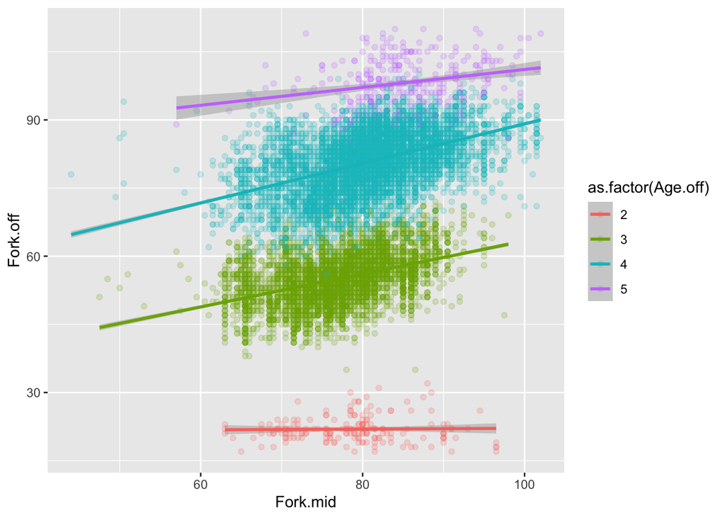

```r
rflk_male_age_plot = ggplot(data=subset(dr,Sex_Final.off == "Male"),aes(x=Fork.mid,y=Fork.off,color=as.factor(Age.off),group=Age.off)) + geom_point(alpha=.2) + geom_smooth(method=lm)
rflk_male_age_plot
```

Males, regression to sire, offspring age as factor

```r
dr = ped
rflk_males_age_sire = lm(Fork.off~Fork.sire*Origin_ped.off +as.factor(Age.off),data=subset(dr,Sex_Final.off == "Male"))
summary(rflk_males_age_sire)
```

```
Call:
lm(formula = Fork.off ~ Fork.sire * Origin_ped.off + as.factor(Age.off),
    data = subset(dr, Sex_Final.off == "Male"))

Residuals:
     Min       1Q   Median       3Q      Max
-22.0695  -3.6440   0.1324   3.7300  26.6434

Coefficients:
                              Estimate Std. Error t value Pr(>|t|)
(Intercept)                   3.112886   0.565570   5.504 3.78e-08 ***
Fork.sire                     0.244496   0.005050  48.411  < 2e-16 ***
Origin_ped.offWild            4.063407   0.675217   6.018 1.81e-09 ***
as.factor(Age.off)3          34.172966   0.418011  81.751  < 2e-16 ***
as.factor(Age.off)4          58.108377   0.416451 139.532  < 2e-16 ***
as.factor(Age.off)5          74.245478   0.530548 139.941  < 2e-16 ***
Fork.sire:Origin_ped.offWild -0.058595   0.008727  -6.714 1.97e-11 ***
---
Signif. codes:  0 '***' 0.001 '**' 0.01 '*' 0.05 '.' 0.1 ' ' 1

Residual standard error: 5.5 on 13001 degrees of freedom
  (1 observation deleted due to missingness)
Multiple R-squared:  0.8738,    Adjusted R-squared:  0.8737
F-statistic: 1.5e+04 on 6 and 13001 DF,  p-value: < 2.2e-16
```

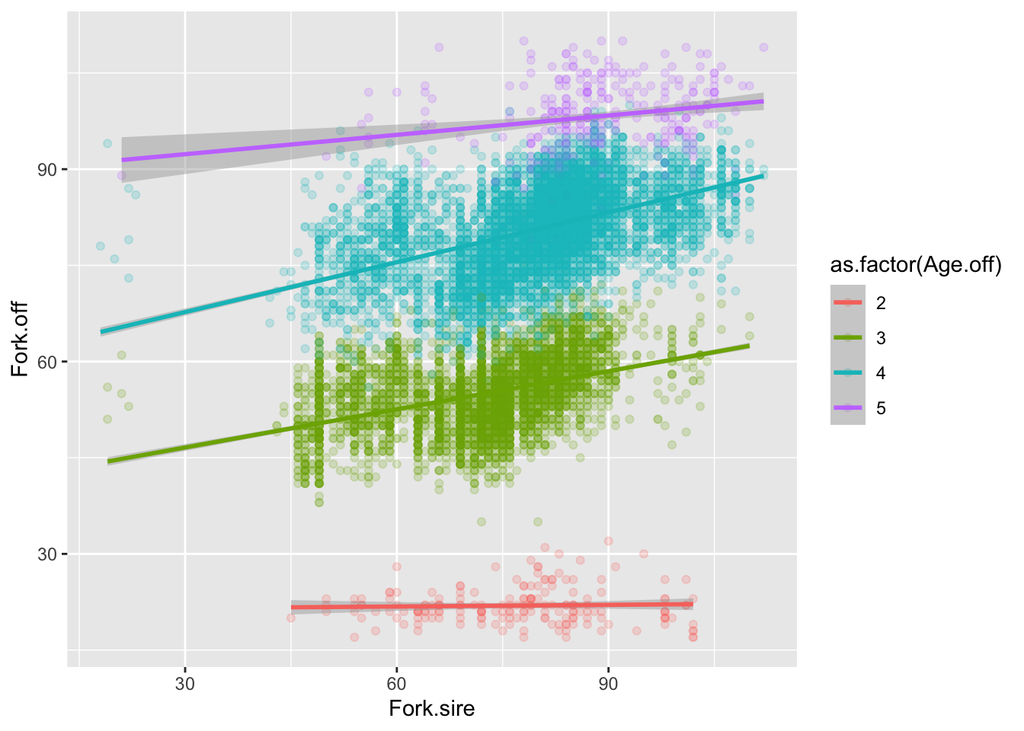

```r
rflk_male_age_sire_plot = ggplot(data=subset(dr,Sex_Final.off == "Male"),aes(x=Fork.sire,y=Fork.off,color=as.factor(Age.off),group=Age.off)) + geom_point(alpha=.2) + geom_smooth(method=lm)
rflk_male_age_sire_plot
```

Males, regression to sire, offspring age AND sire age as factors (no origin)

```r
dr = ped
dr$Agei = paste(dr$Age.sire,dr$Age.off,sep="_")
table(dr$Agei)
```

```
  2_3   2_4   2_5   3_2   3_3   3_4   3_5   4_2   4_3   4_4   4_5   5_2   5_3
    5    17     1    49   895  2155   102   106  3899 15389   529    25   104
  5_4   5_5
 1895   243
```

```r
rflk_males_age2_sire = lm(Fork.off~Fork.sire+as.factor(Age.off)+as.factor(Age.sire),data=subset(dr,Sex_Final.off == "Male"))
summary(rflk_males_age2_sire)
```

```
Call:
lm(formula = Fork.off ~ Fork.sire + as.factor(Age.off) + as.factor(Age.sire),
    data = subset(dr, Sex_Final.off == "Male"))

Residuals:
     Min       1Q   Median       3Q      Max
-22.1635  -3.4693   0.0775   3.4551  26.7159

Coefficients:
                       Estimate Std. Error t value Pr(>|t|)
(Intercept)           12.401195   1.518997   8.164 3.54e-16 ***
Fork.sire              0.439738   0.007195  61.119  < 2e-16 ***
as.factor(Age.off)3   35.159355   0.401066  87.665  < 2e-16 ***
as.factor(Age.off)4   58.420148   0.397158 147.096  < 2e-16 ***
as.factor(Age.off)5   73.757144   0.497410 148.282  < 2e-16 ***
as.factor(Age.sire)3 -18.431104   1.486043 -12.403  < 2e-16 ***
as.factor(Age.sire)4 -25.576052   1.517986 -16.849  < 2e-16 ***
as.factor(Age.sire)5 -30.446366   1.567806 -19.420  < 2e-16 ***
---
Signif. codes:  0 '***' 0.001 '**' 0.01 '*' 0.05 '.' 0.1 ' ' 1

Residual standard error: 5.256 on 13000 degrees of freedom
  (1 observation deleted due to missingness)
Multiple R-squared:  0.8847,    Adjusted R-squared:  0.8847
F-statistic: 1.425e+04 on 7 and 13000 DF,  p-value: < 2.2e-16
```

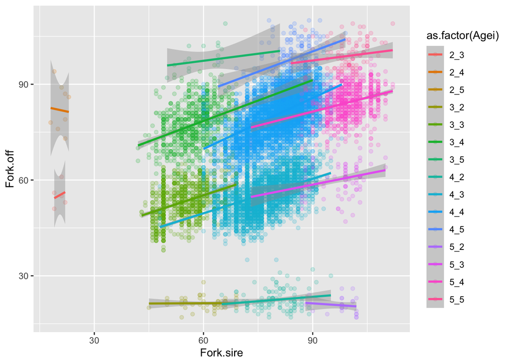

```r
rflk_male_age2_sire_plot = ggplot(data=subset(dr,Sex_Final.off == "Male"),aes(x=Fork.sire,y=Fork.off,color=as.factor(Agei),group=Agei)) + geom_point(alpha=.2) + geom_smooth(method=lm)
rflk_male_age2_sire_plot
```

Males, offspring and sire are age 4 (most common age)

```r
dr = ped

rflk_males_4 = lm(Fork.off~Fork.sire*Origin_ped.off,data=subset(dr,Sex_Final.off == "Male" & Age.off==4 & Age.sire==4))
summary(rflk_males_4)
```

```
Call:
lm(formula = Fork.off ~ Fork.sire * Origin_ped.off, data = subset(dr,
    Sex_Final.off == "Male" & Age.off == 4 & Age.sire == 4))

Residuals:
     Min       1Q   Median       3Q      Max
-21.7212  -3.5659   0.1568   3.6494  20.3824

Coefficients:
                             Estimate Std. Error t value Pr(>|t|)
(Intercept)                  38.65065    0.96859  39.904   <2e-16 ***
Fork.sire                     0.52588    0.01201  43.802   <2e-16 ***
Origin_ped.offWild           -5.47326    2.13713  -2.561   0.0105 *
Fork.sire:Origin_ped.offWild  0.04841    0.02631   1.840   0.0658 .
---
Signif. codes:  0 '***' 0.001 '**' 0.01 '*' 0.05 '.' 0.1 ' ' 1

Residual standard error: 5.428 on 6068 degrees of freedom
  (1 observation deleted due to missingness)
Multiple R-squared:  0.2973,    Adjusted R-squared:  0.297
F-statistic:   856 on 3 and 6068 DF,  p-value: < 2.2e-16
```

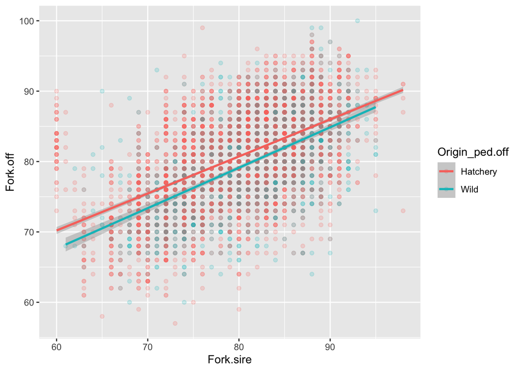

```r
rflk_male_4_plot = ggplot(data=subset(dr,Sex_Final.off == "Male" & Age.off==4 & Age.sire==4),aes(x=Fork.sire,y=Fork.off,color=Origin_ped.off)) + geom_point(alpha=.2) + geom_smooth(method=lm)
rflk_male_4_plot
```

Males, offspring and sire are both age 3

```r
dr = ped

rflk_males_3 = lm(Fork.off~Fork.sire*Origin_ped.off,data=subset(dr,Sex_Final.off == "Male" & Age.off==3 & Age.sire==3))
summary(rflk_males_3)
```

```
Call:
lm(formula = Fork.off ~ Fork.sire * Origin_ped.off, data = subset(dr,
    Sex_Final.off == "Male" & Age.off == 3 & Age.sire == 3))

Residuals:
     Min       1Q   Median       3Q      Max
-12.9232  -3.5411  -0.0588   3.7251  13.0768

Coefficients:
                             Estimate Std. Error t value Pr(>|t|)
(Intercept)                  31.71730    2.01747  15.721   <2e-16 ***
Fork.sire                     0.39196    0.03743  10.473   <2e-16 ***
Origin_ped.offWild            5.21687    4.15244   1.256    0.209
Fork.sire:Origin_ped.offWild -0.08859    0.07593  -1.167    0.244
---
Signif. codes:  0 '***' 0.001 '**' 0.01 '*' 0.05 '.' 0.1 ' ' 1

Residual standard error: 5.078 on 887 degrees of freedom
Multiple R-squared:  0.1321,    Adjusted R-squared:  0.1292
F-statistic:    45 on 3 and 887 DF,  p-value: < 2.2e-16
```

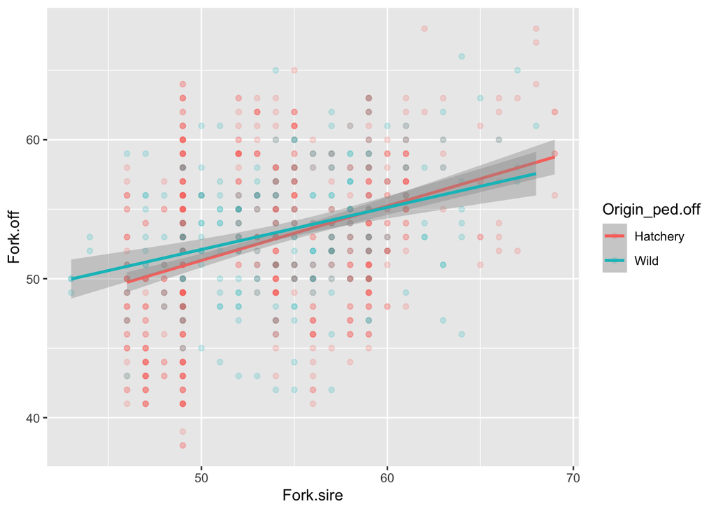

```r
rflk_male_3_plot = ggplot(data=subset(dr,Sex_Final.off == "Male" & Age.off==3 & Age.sire==3),aes(x=Fork.sire,y=Fork.off,color=Origin_ped.off)) + geom_point(alpha=.2) + geom_smooth(method=lm)
rflk_male_3_plot
```

Males, offspring and sire are both age 5

```r
dr = ped

rflk_males_5 = lm(Fork.off~Fork.sire*Origin_ped.off,data=subset(dr,Sex_Final.off == "Male" & Age.off==5 & Age.sire==5))
summary(rflk_males_5)
```

```
Call:
lm(formula = Fork.off ~ Fork.sire * Origin_ped.off, data = subset(dr,
    Sex_Final.off == "Male" & Age.off == 5 & Age.sire == 5))

Residuals:
     Min       1Q   Median       3Q      Max
-14.8204  -3.4184  -0.0933   3.0488  12.0488

Coefficients:
                             Estimate Std. Error t value Pr(>|t|)
(Intercept)                  111.3071    20.4804   5.435 3.82e-07 ***
Fork.sire                     -0.1421     0.2089  -0.680    0.498
Origin_ped.offWild           -24.9591    23.8787  -1.045    0.298
Fork.sire:Origin_ped.offWild   0.2761     0.2414   1.144    0.255
---
Signif. codes:  0 '***' 0.001 '**' 0.01 '*' 0.05 '.' 0.1 ' ' 1

Residual standard error: 4.786 on 101 degrees of freedom
Multiple R-squared:   0.08, Adjusted R-squared:  0.05268
F-statistic: 2.928 on 3 and 101 DF,  p-value: 0.03735
```

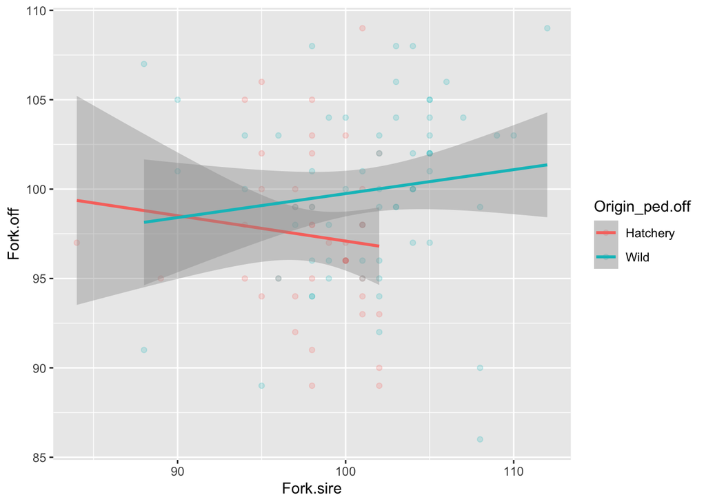

```r
rflk_male_5_plot = ggplot(data=subset(dr,Sex_Final.off == "Male" & Age.off==5 & Age.sire==5),aes(x=Fork.sire,y=Fork.off,color=Origin_ped.off)) + geom_point(alpha=.2) + geom_smooth(method=lm)
rflk_male_5_plot
```

Females, regresssion to mid-parent

```r
dr = ped
dr$Fork.mid = (dr$Fork.dam+dr$Fork.sire)/2
summary(dr$Fork.mid)
```

```
   Min. 1st Qu.  Median    Mean 3rd Qu.    Max.
  44.00   76.00   80.00   79.98   84.00  104.00
```

```r
rflk_females_age = lm(Fork.off~Fork.mid*Origin_ped.off +as.factor(Age.off),data=subset(dr,Sex_Final.off == "Female"))
summary(rflk_females_age)
```

```
Call:
lm(formula = Fork.off ~ Fork.mid * Origin_ped.off + as.factor(Age.off),
    data = subset(dr, Sex_Final.off == "Female"))

Residuals:
     Min       1Q   Median       3Q      Max
-22.3312  -2.5024   0.1153   2.6770  14.2743

Coefficients:
                             Estimate Std. Error t value Pr(>|t|)
(Intercept)                 55.688009   0.868094  64.150   <2e-16 ***
Fork.mid                     0.087666   0.006128  14.305   <2e-16 ***
Origin_ped.offWild           0.514740   0.958280   0.537    0.591
as.factor(Age.off)4         16.410680   0.718968  22.825   <2e-16 ***
as.factor(Age.off)5         27.982766   0.738682  37.882   <2e-16 ***
Fork.mid:Origin_ped.offWild -0.003442   0.011871  -0.290    0.772
---
Signif. codes:  0 '***' 0.001 '**' 0.01 '*' 0.05 '.' 0.1 ' ' 1

Residual standard error: 3.932 on 12399 degrees of freedom
Multiple R-squared:  0.3188,    Adjusted R-squared:  0.3185
F-statistic:  1161 on 5 and 12399 DF,  p-value: < 2.2e-16
```

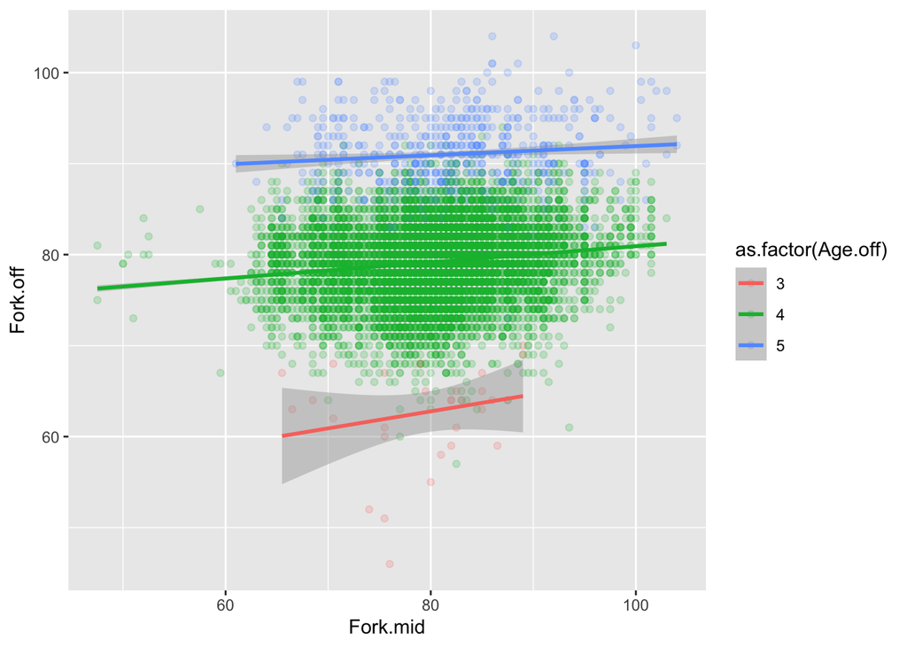

```r
rflk_female_age_plot = ggplot(data=subset(dr,Sex_Final.off == "Female"),aes(x=Fork.mid,y=Fork.off,color=as.factor(Age.off),group=Age.off)) + geom_point(alpha=.2) + geom_smooth(method=lm)
rflk_female_age_plot
```

Females, regression to dam

```r
dr = ped
dr$Fork.mid = (dr$Fork.dam+dr$Fork.sire)/2
summary(dr$Fork.mid)
```

```
   Min. 1st Qu.  Median    Mean 3rd Qu.    Max.
  44.00   76.00   80.00   79.98   84.00  104.00
```

```r
rflk_females_age_dam = lm(Fork.off~Fork.dam*Origin_ped.off +as.factor(Age.off),data=subset(dr,Sex_Final.off == "Female"))
summary(rflk_females_age_dam)
```

```
Call:
lm(formula = Fork.off ~ Fork.dam * Origin_ped.off + as.factor(Age.off),
    data = subset(dr, Sex_Final.off == "Female"))

Residuals:
     Min       1Q   Median       3Q      Max
-21.6715  -2.5122   0.1324   2.6276  14.5810

Coefficients:
                             Estimate Std. Error t value Pr(>|t|)
(Intercept)                 50.280325   0.902602  55.706   <2e-16 ***
Fork.dam                     0.149514   0.006759  22.119   <2e-16 ***
Origin_ped.offWild           0.047506   1.259828   0.038    0.970
as.factor(Age.off)4         16.729082   0.709685  23.573   <2e-16 ***
as.factor(Age.off)5         28.252836   0.729063  38.752   <2e-16 ***
Fork.dam:Origin_ped.offWild  0.002454   0.015498   0.158    0.874
---
Signif. codes:  0 '***' 0.001 '**' 0.01 '*' 0.05 '.' 0.1 ' ' 1

Residual standard error: 3.882 on 12399 degrees of freedom
Multiple R-squared:  0.3363,    Adjusted R-squared:  0.3361
F-statistic:  1257 on 5 and 12399 DF,  p-value: < 2.2e-16
```

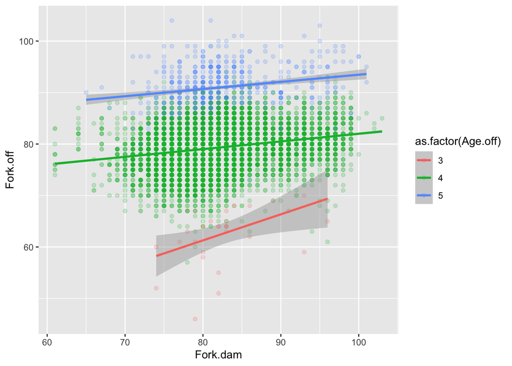

```r
rflk_female_age_dam_plot = ggplot(data=subset(dr,Sex_Final.off == "Female"),aes(x=Fork.dam,y=Fork.off,color=as.factor(Age.off),group=Age.off)) + geom_point(alpha=.2) + geom_smooth(method=lm)
rflk_female_age_dam_plot
```

## Run timing

Males, mid-parent, including year as factor since it varies so among years

```r
dr = ped
dr$Dayofyear.mid = (dr$Dayofyear.dam+dr$Dayofyear.sire)/2
summary(dr$Dayofyear.mid)
```

```
   Min. 1st Qu.  Median    Mean 3rd Qu.    Max.
  139.5   174.5   183.0   181.5   189.0   220.0
```

```r
rRT_males = lm(Dayofyear.off~Dayofyear.mid*Origin_ped.off +as.factor(Year.off),data=subset(dr,Sex_Final.off == "Male"))
summary(rRT_males)
```

```
Call:
lm(formula = Dayofyear.off ~ Dayofyear.mid * Origin_ped.off +
    as.factor(Year.off), data = subset(dr, Sex_Final.off == "Male"))

Residuals:
    Min      1Q  Median      3Q     Max
-50.665  -6.674   0.066   6.430  84.590

Coefficients:
                                  Estimate Std. Error t value Pr(>|t|)
(Intercept)                      134.14331    1.88702  71.087  < 2e-16 ***
Dayofyear.mid                      0.33196    0.01083  30.661  < 2e-16 ***
Origin_ped.offWild               -20.63758    3.81959  -5.403 6.67e-08 ***
as.factor(Year.off)2009           -5.45598    0.32852 -16.608  < 2e-16 ***
as.factor(Year.off)2010           -1.88220    0.35680  -5.275 1.35e-07 ***
as.factor(Year.off)2011            3.67950    0.39123   9.405  < 2e-16 ***
as.factor(Year.off)2012           -5.54502    0.39929 -13.887  < 2e-16 ***
as.factor(Year.off)2013          -17.91164    0.41024 -43.661  < 2e-16 ***
as.factor(Year.off)2014          -20.76479    0.53317 -38.946  < 2e-16 ***
as.factor(Year.off)2015          -37.74311    0.56189 -67.171  < 2e-16 ***
as.factor(Year.off)2016          -24.44538    0.73451 -33.281  < 2e-16 ***
as.factor(Year.off)2017           -8.66476    0.61139 -14.172  < 2e-16 ***
as.factor(Year.off)2018          -18.82777    0.54278 -34.687  < 2e-16 ***
Dayofyear.mid:Origin_ped.offWild   0.10476    0.02089   5.014 5.40e-07 ***
---
Signif. codes:  0 '***' 0.001 '**' 0.01 '*' 0.05 '.' 0.1 ' ' 1

Residual standard error: 10.07 on 12995 degrees of freedom
Multiple R-squared:  0.4727,    Adjusted R-squared:  0.4721
F-statistic: 895.9 on 13 and 12995 DF,  p-value: < 2.2e-16
```

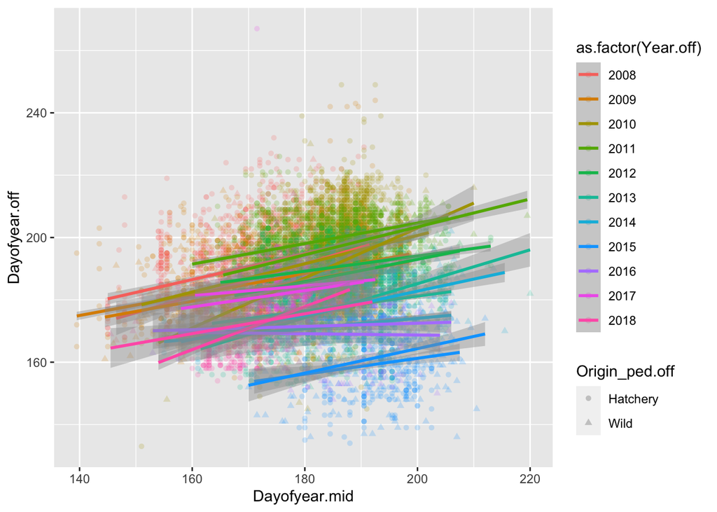

```r
rRT_male_plot = ggplot(data=subset(dr,Sex_Final.off == "Male"),aes(x=Dayofyear.mid,y=Dayofyear.off,color=as.factor(Year.off),pch=Origin_ped.off)) + geom_point(alpha=.2) + geom_smooth(method=lm)
rRT_male_plot
```

Females

```r
dr = ped
dr$Dayofyear.mid = (dr$Dayofyear.dam+dr$Dayofyear.sire)/2
summary(dr$Dayofyear.mid)
```

```
   Min. 1st Qu.  Median    Mean 3rd Qu.    Max.
  139.5   174.5   183.0   181.5   189.0   220.0
```

```r
rRT_females = lm(Dayofyear.off~Dayofyear.mid*Origin_ped.off +as.factor(Year.off),data=subset(dr,Sex_Final.off == "Female"))
summary(rRT_females)
```

```
Call:
lm(formula = Dayofyear.off ~ Dayofyear.mid * Origin_ped.off +
    as.factor(Year.off), data = subset(dr, Sex_Final.off == "Female"))

Residuals:
    Min      1Q  Median      3Q     Max
-55.697  -6.808  -0.253   6.963  56.167

Coefficients:
                                  Estimate Std. Error t value Pr(>|t|)
(Intercept)                      119.10240    2.31671  51.410  < 2e-16 ***
Dayofyear.mid                      0.40708    0.01321  30.816  < 2e-16 ***
Origin_ped.offWild                 5.90518    4.16092   1.419    0.156
as.factor(Year.off)2009           -4.62831    0.38591 -11.993  < 2e-16 ***
as.factor(Year.off)2010           -2.42888    0.35635  -6.816  9.8e-12 ***
as.factor(Year.off)2011            4.48609    0.48285   9.291  < 2e-16 ***
as.factor(Year.off)2012           -5.45068    0.35238 -15.468  < 2e-16 ***
as.factor(Year.off)2013          -19.24116    0.38227 -50.334  < 2e-16 ***
as.factor(Year.off)2014          -21.12705    0.47150 -44.808  < 2e-16 ***
as.factor(Year.off)2015          -37.38340    0.52208 -71.604  < 2e-16 ***
as.factor(Year.off)2016          -28.61831    0.67867 -42.168  < 2e-16 ***
as.factor(Year.off)2017           -8.99193    0.58305 -15.422  < 2e-16 ***
as.factor(Year.off)2018          -17.58848    0.50578 -34.775  < 2e-16 ***
Dayofyear.mid:Origin_ped.offWild  -0.03729    0.02283  -1.633    0.102
---
Signif. codes:  0 '***' 0.001 '**' 0.01 '*' 0.05 '.' 0.1 ' ' 1

Residual standard error: 10.58 on 12391 degrees of freedom
Multiple R-squared:  0.4879,    Adjusted R-squared:  0.4873
F-statistic:   908 on 13 and 12391 DF,  p-value: < 2.2e-16
```

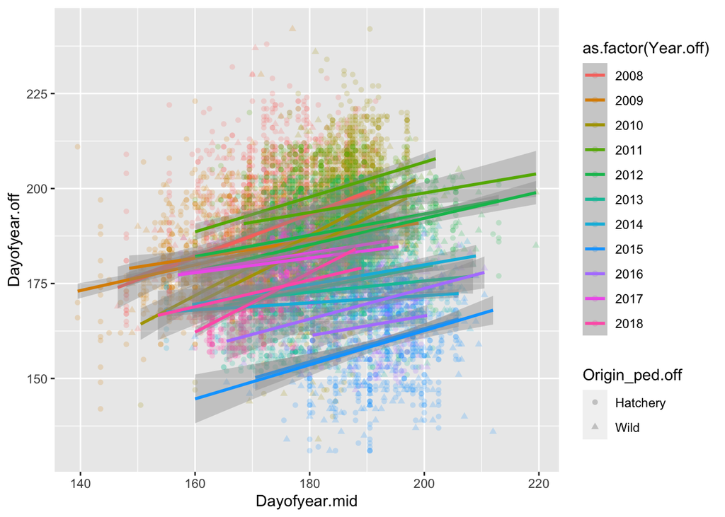

```r
rRT_female_plot = ggplot(data=subset(dr,Sex_Final.off == "Female"),aes(x=Dayofyear.mid,y=Dayofyear.off,color=as.factor(Year.off),pch=Origin_ped.off)) + geom_point(alpha=.2) + geom_smooth(method=lm)
rRT_female_plot
```

## Age

Males. Will do this several ways. First, see determine if there is a relationship between offspring and sire age via contingency table analyses

```r
dr = ped
maleagetable = table(dr$Age.off,dr$Age.sire)
maleagetable
```

```
        2     3     4     5
  2     0    49   106    25
  3     5   895  3899   104
  4    17  2155 15389  1895
  5     1   102   529   243
```

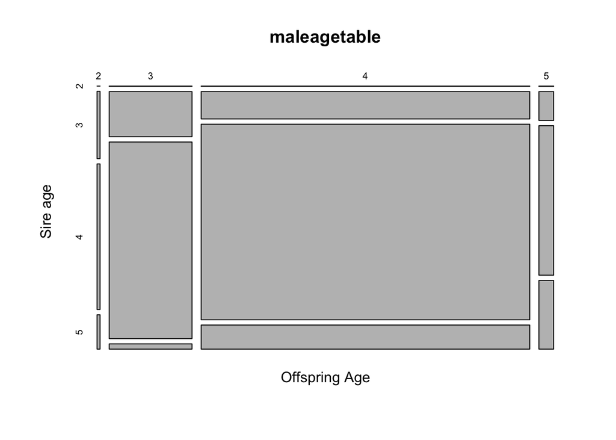

```r
mosaicplot(maleagetable,xlab="Offspring Age",ylab="Sire age")
```

```r
maleagechisq = chisq.test(maleagetable,simulate.p.value = T)
round(maleagechisq$observed - maleagechisq$expected,2)
```

```
          2       3       4       5
  2   -0.16   26.33  -35.11    8.94
  3    0.56  277.45   55.35 -333.36
  4   -0.61 -295.56  136.70  159.47
  5    0.21   -8.21 -156.95  164.95
```

Age appears to be heritable - a sire is more likely than expected to produce a male offspring of the same age (excluded age 2). Let’s see if this differs between hatchery and wild

```r
dr = ped
drwild = subset(dr,Origin_ped.off == "Wild")
drhatchery = subset(dr,Origin_ped.off =="Hatchery")
maleagetablewild = table(drwild$Age.off,drwild$Age.sire)
maleagetablewild
```

```
       2    3    4    5
  2    0    1    0    0
  3    5  241  210    4
  4   16  886 2709  382
  5    1   84  345  145
```

```r
maleagetablehatchery = table(drhatchery$Age.off,drhatchery$Age.sire)
maleagetablehatchery
```

```
        2     3     4     5
  2     0    48   106    25
  3     0   654  3689   100
  4     1  1269 12680  1513
  5     0    18   184    98
```

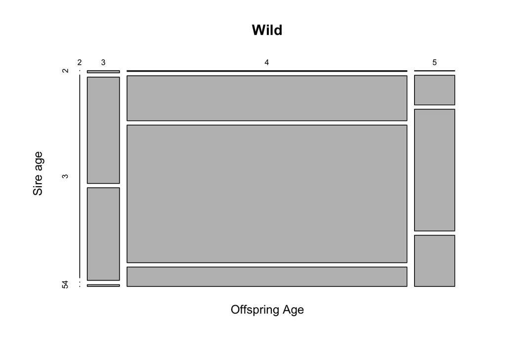

```r
mosaicplot(maleagetablewild,xlab="Offspring Age",ylab="Sire age",main="Wild")
```

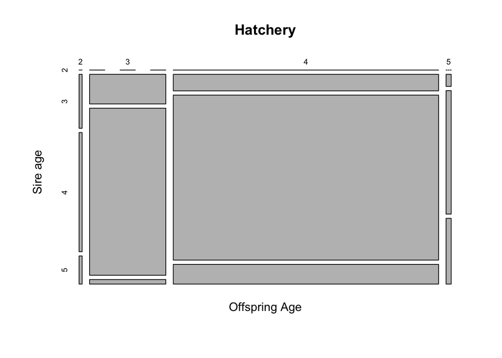

```r
mosaicplot(maleagetablehatchery,xlab="Offspring Age",ylab="Sire age",main="Hatchery")
```

```r
maleagechisqwild = chisq.test(maleagetablewild,simulate.p.value = T)
print("wild")
```

```
[1] "wild"
```

```r
round((maleagechisqwild$observed - maleagechisqwild$expected),2)
```

```
         2      3      4      5
  2   0.00   0.76  -0.65  -0.11
  3   2.99 130.14 -88.56 -44.57
  4  -1.47 -76.32 117.40 -39.61
  5  -1.52 -54.58 -28.20  84.29
```

```r
maleagechisqhatchery = chisq.test(maleagetablehatchery,simulate.p.value = T)
print("hatchery")
```

```
[1] "hatchery"
```

```r
round((maleagechisqhatchery$observed - maleagechisqhatchery$expected),2)
```

```
          2       3       4       5
  2   -0.01   30.53  -40.28    9.76
  3   -0.22  220.49   58.10 -278.37
  4    0.24 -239.75   43.35  196.16
  5   -0.01  -11.27  -61.17   72.45
```

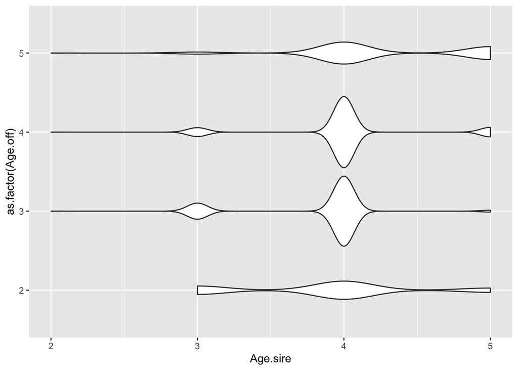

```r
ageplotvio = ggplot(data = subset(ped,Sex_Final.off=="Male"),aes(x=Age.sire,y=as.factor(Age.off))) + geom_violin()
ageplotvio
```

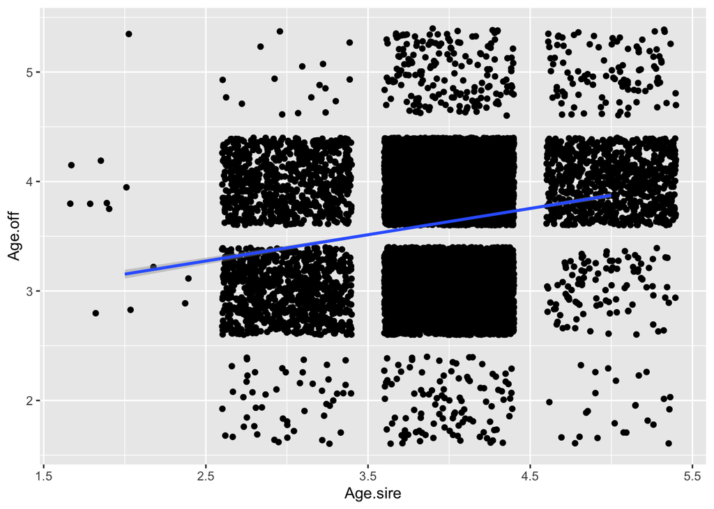

```r
ageplotreg = ggplot(data = subset(ped,Sex_Final.off=="Male"),aes(x=Age.sire,y=Age.off)) + geom_jitter() + geom_smooth(method=lm)
ageplotreg
```

Try treating age as just a normal trait

```r
dr = ped
rage_males = lm(Age.off~Age.sire*Origin_ped.off ,data=subset(dr,Sex_Final.off == "Male"))
summary(rage_males)
```

```
Call:
lm(formula = Age.off ~ Age.sire * Origin_ped.off, data = subset(dr,
    Sex_Final.off == "Male"))

Residuals:
     Min       1Q   Median       3Q      Max
-1.86549 -0.55344  0.04139  0.44656  1.75861

Coefficients:
                            Estimate Std. Error t value Pr(>|t|)
(Intercept)                  2.30525    0.04924  46.817  < 2e-16 ***
Age.sire                     0.31205    0.01229  25.381  < 2e-16 ***
Origin_ped.offWild           0.58248    0.08233   7.075 1.57e-12 ***
Age.sire:Origin_ped.offWild -0.04433    0.02111  -2.100   0.0357 *
---
Signif. codes:  0 '***' 0.001 '**' 0.01 '*' 0.05 '.' 0.1 ' ' 1

Residual standard error: 0.52 on 13005 degrees of freedom
Multiple R-squared:  0.1264,    Adjusted R-squared:  0.1262
F-statistic: 627.3 on 3 and 13005 DF,  p-value: < 2.2e-16
```

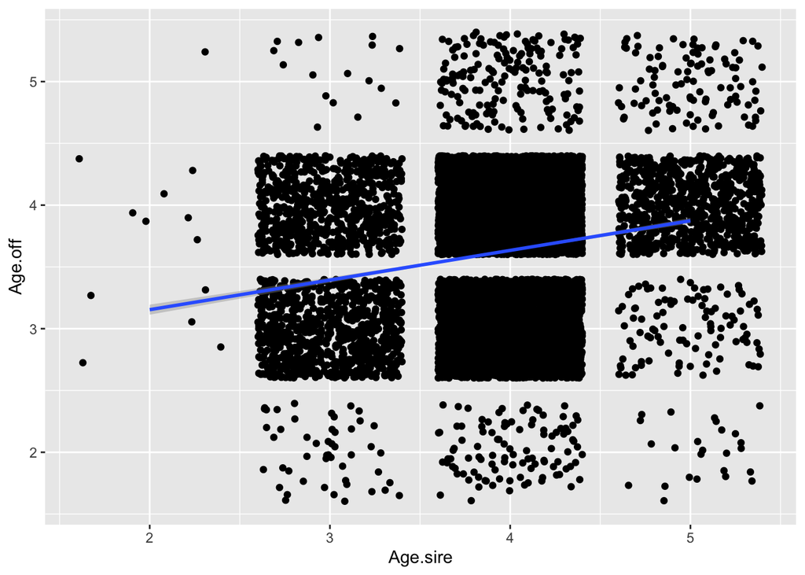

```r
ageplotreg = ggplot(data = subset(ped,Sex_Final.off=="Male"),aes(x=Age.sire,y=Age.off)) + geom_jitter() + geom_smooth(method=lm)
ageplotreg
```

Note, could try binomial or multinomial regression, but I find interpreting the results from those models to be very difficult.

## Fitness (offspring number)

Males

```r
dr = ped
dr$noff.mid = (dr$noff.dam+dr$noff.sire)/2
summary(dr$noff.mid)
```

```
   Min. 1st Qu.  Median    Mean 3rd Qu.    Max.
   1.00   11.00   28.00   37.78   55.00  170.00
```

```r
rfit_males = lm(noff.off~noff.mid*Origin_ped.off +as.factor(Year.off)+Final_Status_ped.off,data=subset(dr,Sex_Final.off == "Male"))
summary(rfit_males)
```

```
Call:
lm(formula = noff.off ~ noff.mid * Origin_ped.off + as.factor(Year.off) +
    Final_Status_ped.off, data = subset(dr, Sex_Final.off ==
    "Male"))

Residuals:
    Min      1Q  Median      3Q     Max
-12.952  -0.410  -0.209   0.177  95.045

Coefficients:
                                       Estimate Std. Error t value Pr(>|t|)
(Intercept)                           12.995015   0.181384  71.644  < 2e-16 ***
noff.mid                              -0.002676   0.001164  -2.300   0.0215 *
Origin_ped.offWild                     0.849816   0.137111   6.198 5.89e-10 ***
as.factor(Year.off)2009               -0.987223   0.110675  -8.920  < 2e-16 ***
as.factor(Year.off)2010               -1.047255   0.116395  -8.997  < 2e-16 ***
as.factor(Year.off)2011               -1.304890   0.134922  -9.671  < 2e-16 ***
as.factor(Year.off)2012               -1.552317   0.136448 -11.377  < 2e-16 ***
as.factor(Year.off)2013               -1.406031   0.138487 -10.153  < 2e-16 ***
as.factor(Year.off)2014               -1.736228   0.184797  -9.395  < 2e-16 ***
as.factor(Year.off)2015               -3.139313   0.186521 -16.831  < 2e-16 ***
as.factor(Year.off)2016               -4.508483   0.257355 -17.519  < 2e-16 ***
as.factor(Year.off)2017               -2.785373   0.219149 -12.710  < 2e-16 ***
as.factor(Year.off)2018               -2.158891   0.197823 -10.913  < 2e-16 ***
Final_Status_ped.offSpawning Grounds -11.523098   0.148464 -77.615  < 2e-16 ***
noff.mid:Origin_ped.offWild            0.034275   0.041529   0.825   0.4092
---
Signif. codes:  0 '***' 0.001 '**' 0.01 '*' 0.05 '.' 0.1 ' ' 1

Residual standard error: 3.548 on 12994 degrees of freedom
Multiple R-squared:  0.3398,    Adjusted R-squared:  0.3391
F-statistic: 477.8 on 14 and 12994 DF,  p-value: < 2.2e-16
```

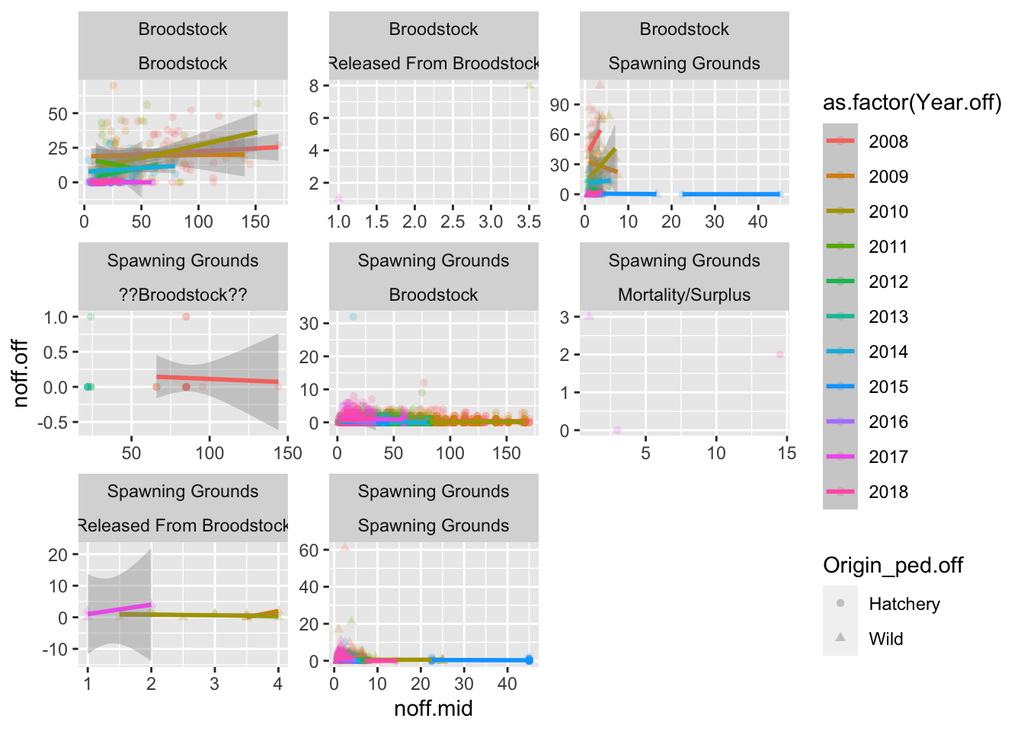

```r
rfit_male_plot = ggplot(data=subset(dr,Sex_Final.off == "Male"),aes(x=noff.mid,y=noff.off,color=as.factor(Year.off),pch=Origin_ped.off)) + geom_point(alpha=.2) + geom_smooth(method=lm)  + facet_wrap(vars(Final_Status_ped.off,Final_Status_ped.dam),scales = "free")
rfit_male_plot
```